# Overview: Hybrid Bayesian Optimization Strategy

Purpose: This notebook demonstrates a hybrid approach for black-box optimization using Bayesian methods. Key components:

Gaussian Process surrogate modeling Acquisition functions (Expected Improvement, Upper Confidence Bound) Hybrid candidate generation (global sampling + trust region + targeted perturbations) Optional SVM filtering and ARD-based feature screening Visualization tools for diagnostics

### Directions for Use:

1. **Run the setup cells** to load functions for GP fitting, acquisition functions, perturbations, and visualisations etc.
2. **Provide your observed data** (`X`, `Y`) from previous rounds.
3. **Fit the GP model** and compute acquisition scores.
4. **Visualise results** to guide your next round of submissions.
5. **Generate candidate queries** using the hybrid strategy.

```python
import numpy as np
import pandas as pd
from typing import Optional
from dataclasses import dataclass

from sklearn.gaussian_process import GaussianProcessRegressor
from sklearn.gaussian_process.kernels import Matern, WhiteKernel, ConstantKernel
from sklearn.preprocessing import StandardScaler
from sklearn.svm import SVC
from sklearn.exceptions import ConvergenceWarning
import warnings
from scipy.stats import norm

import matplotlib.pyplot as plt
from matplotlib.cm import ScalarMappable
from matplotlib.colors import Normalize

# Suppress only ConvergenceWarning from sklearn (safe and targeted)
warnings.filterwarnings("ignore", category=ConvergenceWarning)
```

## Configuration Parameters

Explain the role of BOConfig:

Acquisition knobs (xi, kappa) Candidate generation settings (n_global_factor, trust_radius_base) GP fitting options (nu, standardize_y) SVM and ARD toggles Perturbation controls (use_perturbations, perturb_rate_base)

```python
# Config dataclass (tweak here)
# ----------------------------
@dataclass
class BOConfig:
    # Acquisition knobs
    xi: float = 0.01             # EI exploration parameter
    kappa: float = 2.0           # UCB kappa

    # Candidate generators
    n_global_factor: int = 2000  # n_global = n_global_factor * min(D, 8)
    n_trust_base: int = 16       # n_trust = n_trust_base + 8 * min(D, 8)
    trust_radius_base: float = 0.03  # trust_radius = base / sqrt(D)

    # GP fitting
    nu: float = 2.5
    standardize_y: bool = True
    n_restarts_min: int = 30
    n_restarts_max: int = 60

    # SVM layer (toggle)
    use_svm: bool = True
    svm_kernel: str = "rbf"      # 'rbf' (recommended), 'linear', 'poly'
    svm_C: float = 1.0
    svm_gamma: str = "scale"
    svm_high_quantile: float = 0.70  # top 30% labelled HIGH by default
    svm_keep_frac: float = 0.50      # keep at least 50% of candidates after SVM filter

    # Feature screening
    use_feature_screen: bool = True
    ard_rel_threshold: float = 0.15  # drop dims with relative sensitivity below threshold

    # Scalability
    max_fit_points: int = 2000  # cap for GP fit (subsample if larger)
    random_state: int = 0

    # Perturbations
    use_perturbations: bool = True
    perturb_rate_base: float = 0.05   # used in max(0.02, perturb_rate_base / sqrt(D))
```

## Core Functions

### Gaussian Process Model

- fit_gp(X, Y, cfg): Fits GP with ARD Matern kernel and noise term.

```python
def fit_gp(
    X: np.ndarray,
    Y: np.ndarray,
    cfg: BOConfig,
) -> GaussianProcessRegressor:
    """Fit ARD Matern(ν=cfg.nu) + White GP with dimension-aware bounds; standardise Y if requested."""

    if X.ndim == 1:
        X = X.reshape(-1, 1)
    n, D = int(X.shape[0]), int(X.shape[1])


    # Optionally subsample for scalability
    if n > cfg.max_fit_points:
        rng = np.random.default_rng(cfg.random_state)
        idx = rng.choice(n, size=cfg.max_fit_points, replace=False)
        X_fit = X[idx]
        Y_fit_raw = Y[idx]
    else:
        X_fit = X
        Y_fit_raw = Y

    # Standardise Y (safer kernel bounds)
    if cfg.standardize_y:
        scaler = StandardScaler(with_mean=True, with_std=True)
        Y_fit = scaler.fit_transform(Y_fit_raw.reshape(-1, 1)).ravel()
        normalize_y = False
    else:
        Y_fit = Y_fit_raw
        normalize_y = True


    # Per-dimension spread and geometric mean (more robust in heterogeneous D)
    s_per_dim = np.std(X_fit, axis=0) + 1e-12
    gm_s = float(np.exp(np.mean(np.log(s_per_dim))))
    length_scale_lower = 0.25 * gm_s / max(np.sqrt(D), 1.0)
    length_scale_upper = min(30.0, 6.0 * gm_s * max(np.sqrt(D), 1.0))

    # Heuristic ARD init
    c_init = 1.0   # neutral; tune to 0.5–1.5 if needed
    ls0 = c_init * (np.std(X_fit, axis=0) + 1e-12)
    amp_bounds = (1e-6, 1e3) if cfg.standardize_y else (1e-6, 1e4)
    kernel = ConstantKernel(1.0, amp_bounds) * Matern(length_scale=ls0,
                                                      length_scale_bounds=(max(1e-3,length_scale_lower),
                                                      float(length_scale_upper)),
                                                      nu=cfg.nu) \
                                                      + WhiteKernel(noise_level=1e-4,
                                                        noise_level_bounds=(1e-12 if cfg.standardize_y else 1e-14,
                                                        0.75 if cfg.standardize_y else max(1e-3, 0.5 * float(np.std(Y_fit_raw)))))
    # Restarts scaled by D & n
    n_restarts = int(20 + 5 * min(D, 8) + 5 * np.log10(max(n, 10)))
    n_restarts = min(max(n_restarts, cfg.n_restarts_min), cfg.n_restarts_max)

    gp = GaussianProcessRegressor(
        kernel=kernel,
        normalize_y=normalize_y,
        n_restarts_optimizer=n_restarts,
        random_state=cfg.random_state)
    gp.fit(X_fit, Y_fit)
    return gp
```

### Acquisition Functions

- expected_improvement(...)
- upper_confidence_bound(...)

```python
# ----------------------------
# Acquisition functions (EI/UCB)
# ----------------------------

def expected_improvement(Xc, gp, Y_best, xi=0.01, eps=1e-9):
    """ Numerically stable EI (protect against std→0) """
    mean, std = gp.predict(Xc, return_std=True)
    std = np.maximum(std, eps)
    imp = mean - Y_best - xi
    Z = imp / std
    ei = imp * norm.cdf(Z) + std * norm.pdf(Z)
    # For std≈0: EI should be ~max(0, imp)
    ei[std <= eps] = np.maximum(0.0, imp[std <= eps])
    return ei


def upper_confidence_bound(Xc, gp, kappa=2.0):
    mean, std = gp.predict(Xc, return_std=True)
    return mean + kappa * std
```

### 3.3 Feature Screening & SVM

- screen_dimensions_by_ard(...)
- train_svm_classifier(...)

```python
# ----------------------------
# Feature screening (ARD)
# ----------------------------
def screen_dimensions_by_ard(gp: GaussianProcessRegressor, threshold: float = 0.15) -> Optional[np.ndarray]:
    """Return boolean mask of kept dimensions using ARD sensitivities (1/length-scale)."""
    try:
        matern = gp.kernel_.k1.k2
        ls = np.asarray(matern.length_scale, dtype=float)
        sens = 1.0 / (ls + 1e-12)
        rel = sens / (np.max(sens) + 1e-12)
        keep = rel >= threshold
        return keep if np.sum(keep) >= 1 else None
    except Exception:
        return None


def train_svm_classifier(X: np.ndarray, Y: np.ndarray, cfg: BOConfig) -> Optional[SVC]:
    """Soft-margin kernel SVM to label HIGH vs LOW performance."""
    if not cfg.use_svm:
        return None
    if X.ndim == 1:
        X = X.reshape(-1, 1)
    q = np.quantile(Y, cfg.svm_high_quantile)
    y_cls = (Y >= q).astype(int)
    if y_cls.sum() < 2 or (len(y_cls) - y_cls.sum()) < 2 or len(y_cls) < 12:
        return None
    svm = SVC(C=cfg.svm_C, kernel=cfg.svm_kernel, gamma=cfg.svm_gamma,
              probability=False, random_state=cfg.random_state)
    svm.fit(X, y_cls)
    return svm
```

### Candidate Generation

- _lhs(...): Latin Hypercube Sampling
- _format_for_portal(...): Portal formatting
- generate_perturbations(...): Local refinement

```python
# ----------------------------
# Portal formatting (six dp)
# ----------------------------
def _format_for_portal(x: np.ndarray) -> str:
    """Clip to [0, 0.999999] and format as hyphen-separated 6 dp (portal requirement)."""
    x = np.clip(np.asarray(x, float), 0.0, 1.0 - 1e-6)
    return "-".join(f"{v:.6f}" for v in x)  # matches your Week-3 formatting


# ----------------------------
# Utility: LHS in [0,1]^d
# ----------------------------
def _lhs(n: int, d: int, rng: np.random.Generator) -> np.ndarray:
    """Simple Latin Hypercube Sampling in [0,1]^d."""
    cut = np.linspace(0, 1, n + 1)
    a, b = cut[:-1], cut[1:]
    X = rng.uniform(a, b, size=(d, n)).T  # shape (n, d)
    for j in range(d):
        rng.shuffle(X[:, j])
    return X

def generate_perturbations(top_points, perturbation_rate=0.05, bounds=(0, 1), rng=None):
    rng = np.random.default_rng(0) if rng is None else rng
    perturbed_points = []
    for point in top_points:
        delta = rng.uniform(-perturbation_rate, perturbation_rate, size=point.shape)
        p = np.clip(point + delta, bounds[0], bounds[1])
        perturbed_points.append(p)
    return np.array(perturbed_points)
```

### Query Proposal

- propose_next_queries(...): Combines global, trust-region, and perturbation candidates; applies SVM filter and ranks by EI/UCB.

```python
def propose_next_queries(X: np.ndarray, Y: np.ndarray, gp: GaussianProcessRegressor,
                               cfg: BOConfig, k_final: int = 5):
    """Global LHS + trust-region; optional SVM pre-filter; EI/UCB ranking; portal formatting."""
    rng = np.random.default_rng(cfg.random_state)
    if X.ndim == 1:
        X = X.reshape(-1, 1)
    n, D = int(X.shape[0]), int(X.shape[1])

    # --- Get current best on GP training scale if available ---
    try:
        Y_train = gp.y_train_
        Y_best = float(np.max(Y_train))
        X_train = gp.X_train_
        X_best = X_train[int(np.argmax(Y_train))]
    except Exception:
        Y_best = float(np.max(Y))
        X_best = X[int(np.argmax(Y))]

    # --- Candidate counts + trust region ---
    n_global = cfg.n_global_factor * min(D, 8)
    n_trust  = cfg.n_trust_base + 8 * min(D, 8)
    trust_radius = cfg.trust_radius_base / max(np.sqrt(D), 1.0)


    # --- Global candidates via LHS --
    Xg = _lhs(n_global, D, rng)

    # --- Local trust-region candidates ---
    deltas = rng.uniform(-trust_radius, trust_radius, size=(n_trust, D))
    Xt = np.clip(X_best + deltas, 0.0, 1.0 - 1e-6)

    # --- APPLY ARD FEATURE SCREENING TO CANDIDATES -
    dim_mask = np.ones(D, dtype=bool)
    if cfg.use_feature_screen:
        ard_mask = screen_dimensions_by_ard(gp, threshold=cfg.ard_rel_threshold)
        if ard_mask is not None and ard_mask.sum() >= 1:
            dim_mask = ard_mask
            # Use observed median to anchor unimportant dims
            x_med = np.median(X, axis=0)
            # For global candidates, overwrite dropped dims with the median
            Xg[:, ~dim_mask] = x_med[~dim_mask]
            # For trust candidates, also reduce variation in dropped dims
            Xt[:, ~dim_mask] = x_med[~dim_mask]


    # --- TARGETED PERTURBATIONS AROUND TOP-m OBSERVED POINTS ---
    # Decide whether to add targeted perturbations
    if cfg.use_perturbations:
        # Select m top points by observed Y to refine promising regions
        # Scales naturally across 2–8D: 2..5 points
        m = min(5, max(2, D // 2))
        top_idx = np.argsort(Y)[-m:]
        top_points = X[top_idx]

        # Adaptive perturbation rate: smaller in higher dimensions
        perturb_rate = max(0.02, cfg.perturb_rate_base / np.sqrt(D))

        # Generate bounded perturbations around top points
        Xp = generate_perturbations(
            top_points,
            perturbation_rate=perturb_rate,
            bounds=(0.0, 1.0),
            rng=rng
        )

        # If ARD screening is active, respect the mask for perturbations too:
        # Snap dropped dims to median (reduces noise in irrelevant directions)
        if 'dim_mask' in locals() and dim_mask is not None and dim_mask.sum() >= 1 and dim_mask.sum() < D:
            x_med = np.median(X, axis=0)
            Xp[:, ~dim_mask] = x_med[~dim_mask]

        # Combine global + trust-region + perturbations
        Xc = np.vstack([Xg, Xt, Xp])

    else:
        # No perturbations: combine only global + trust-region
        Xc = np.vstack([Xg, Xt])

    # --- Optional SVM pre-filter (RELAXED GATING) ---
    svm = train_svm_classifier(X, Y, cfg)
    if svm is not None and len(Xc) > 0:
        if hasattr(svm, "decision_function"):
            scores = svm.decision_function(Xc)
            # Keep top fraction by SVM score (cfg.svm_keep_frac); ensure a minimum pool remains
            q = cfg.svm_keep_frac
            thr = np.quantile(scores, 1.0 - q)
            keep_idx = np.where(scores >= thr)[0]
        else:
            y_hat = svm.predict(Xc)
            keep_idx = np.where(y_hat == 1)[0]

        # Ensure we still keep enough candidates to rank
        min_keep = max(k_final * 5, int(0.25 * len(Xc)))
        if len(keep_idx) >= min_keep:
            Xc = Xc[keep_idx]


    # --- Acquisition scoring ---
    ei  = expected_improvement(Xc, gp, Y_best=Y_best, xi=cfg.xi)
    ucb = upper_confidence_bound(Xc, gp, kappa=cfg.kappa)

    # --- Lexsort: primary EI, secondary UCB ---
    order = np.lexsort((-ucb, -ei))
    Xc_sorted = Xc[order]

    # --- Deduplicate by portal formatting ---
    seen, numeric, formatted = set(), [], []
    for x in Xc_sorted:
        fx = _format_for_portal(x)
        if fx not in seen:
            seen.add(fx)
            numeric.append(x)
            formatted.append(fx)
            if len(numeric) >= k_final:
                break
    return numeric, formatted
```

### Visualization Utilities

- plot_2d_ei_slice(...): EI + GP mean contour (optional)
- plot_acquisition_functions(...): EI/UCB overlays
- plot_gp_slice(...): 1D/2D GP slices
- pairplot_ei(...): Multi-pair EI diagnostics

```python
# --- Plotting: 2D EI contour slices (optional) ---
def plot_2d_ei_slice(X, Y, gp, d1, d2, n_points=100, Y_best=None):
    """
    Vary two dimensions (d1, d2); fix others at median.
    Show GP mean contours and EI contours; mark EI slice maximum.
    """

    # Use GP training scale for Y_best by default
    if Y_best is None:
        Y_best = float(np.max(gp.y_train_))

    fixed = np.median(X, axis=0)
    g1 = np.linspace(0, 1, n_points)
    g2 = np.linspace(0, 1, n_points)
    G1, G2 = np.meshgrid(g1, g2)

    X_full = np.tile(fixed, (n_points*n_points, 1))
    X_full[:, d1] = G1.ravel()
    X_full[:, d2] = G2.ravel()

    mean, std = gp.predict(X_full, return_std=True)
    ei = expected_improvement(X_full, gp, Y_best=Y_best)

    mean_2d = mean.reshape(n_points, n_points)
    ei_2d = ei.reshape(n_points, n_points)

    # EI max index on grid
    max_idx = np.unravel_index(np.argmax(ei_2d), ei_2d.shape)
    max_x1 = g1[max_idx[1]]  # note meshgrid col/row indices
    max_x2 = g2[max_idx[0]]

    fig, ax = plt.subplots(1, 2, figsize=(14, 5))

    c0 = ax[0].contourf(G1, G2, mean_2d, cmap='viridis')
    fig.colorbar(c0, ax=ax[0])
    ax[0].scatter(X[:, d1], X[:, d2], color='red', s=20, label='Observed')
    ax[0].set_title(f"GP mean (dims {d1+1} vs {d2+1})")
    ax[0].set_xlabel(f"Dim {d1+1}")
    ax[0].set_ylabel(f"Dim {d2+1}")
    ax[0].legend(loc='upper right')

    c1 = ax[1].contourf(G1, G2, ei_2d, cmap='plasma')
    fig.colorbar(c1, ax=ax[1])
    ax[1].scatter(max_x1, max_x2, color='black', s=80, marker='*', label='EI slice max')
    ax[1].set_title(f"EI (dims {d1+1} vs {d2+1})")
    ax[1].set_xlabel(f"Dim {d1+1}")
    ax[1].set_ylabel(f"Dim {d2+1}")
    ax[1].legend(loc='upper right')

    plt.tight_layout()
    plt.show()


def plot_acquisition_functions(X_grid, ei_scores, ucb_scores):
    plt.figure(figsize=(10, 6))
    plt.plot(X_grid, ei_scores, label='Expected Improvement', color='green')
    plt.plot(X_grid, ucb_scores, label='Upper Confidence Bound', color='orange')
    plt.xlabel('Input')
    plt.ylabel('Acquisition Score')
    plt.title('Acquisition Functions')
    plt.legend()
    plt.show()


# NEW FUNCTION: Handles 1D and 2D slices for high-dimensional input
def plot_gp_slice(X, Y, gp, dims_to_vary=[0], query_point=None, beta=1.96, n_points=50):
    """
    Visualize GP predictions for high-dimensional input by varying selected dimensions
    and fixing others at their median values.
    dims_to_vary: list of dimension indices to vary (1D or 2D slice)
    """
    fixed_values = np.median(X, axis=0)

    if len(dims_to_vary) == 1:
        # 1D slice
        var_dim = dims_to_vary[0]
        X_grid = np.linspace(0, 1, n_points)
        X_full = np.tile(fixed_values, (n_points, 1))
        X_full[:, var_dim] = X_grid
        mean, std = gp.predict(X_full, return_std=True)

        plt.figure(figsize=(10, 6))
        plt.scatter(X[:, var_dim], Y, color='red', label='Observed Points')
        plt.plot(X_grid, mean, color='blue', label='GP Posterior Mean')
        plt.fill_between(X_grid, mean - beta * std, mean + beta * std,
                         alpha=0.2, color='blue', label='95% Confidence Interval')

        # Highlight query point
        if query_point is not None:
            plt.scatter(query_point[var_dim], gp.predict(query_point.reshape(1, -1))[0],
                        color='black', s=100, marker='*', label='Chosen Query')

        # Cleaner markers + labels (no arrows)
        plt.scatter(X_grid[int(n_points*0.7)], mean[int(n_points*0.7)],
                    color='blue', s=80, marker='o', label='Posterior Mean')
        plt.text(X_grid[int(n_points*0.7)] + 0.02, mean[int(n_points*0.7)],
                 'Posterior Mean', color='blue', fontsize=9)

        plt.scatter(X_grid[int(n_points*0.3)], mean[int(n_points*0.3)] + beta * std[int(n_points*0.3)],
                    color='gray', s=80, marker='o', label='Uncertainty')
        plt.text(X_grid[int(n_points*0.3)] + 0.02,
                 mean[int(n_points*0.3)] + beta * std[int(n_points*0.3)],
                 'Uncertainty', color='gray', fontsize=9)


        plt.xlabel(f'Dimension {var_dim+1}')
        plt.ylabel('Output')
        plt.title(f'1D Slice (Other dims fixed at median)')
        plt.legend()
        plt.show()

    elif len(dims_to_vary) == 2:
        # 2D slice
        d1, d2 = dims_to_vary
        grid1 = np.linspace(0, 1, n_points)
        grid2 = np.linspace(0, 1, n_points)
        X_full = np.tile(fixed_values, (n_points * n_points, 1))
        X_full[:, d1] = np.repeat(grid1, n_points)
        X_full[:, d2] = np.tile(grid2, n_points)
        mean, _ = gp.predict(X_full, return_std=True)

        Z = mean.reshape(n_points, n_points)
        plt.figure(figsize=(8, 6))
        plt.contourf(grid1, grid2, Z, cmap='viridis')
        plt.colorbar(label='GP Posterior Mean')
        plt.scatter(X[:, d1], X[:, d2], color='red', label='Observed Points')

        # Highlight query point
        if query_point is not None:
            plt.scatter(query_point[d1], query_point[d2], color='black', s=100, marker='*', label='Chosen Query')

        plt.xlabel(f'Dimension {d1+1}')
        plt.ylabel(f'Dimension {d2+1}')
        plt.title(f'2D Slice (Other dims fixed at median)')
        plt.legend()
        plt.show()



def pairplot_ei(
    X: np.ndarray,
    Y: np.ndarray,
    gp,
    n_dims: int = 4,
    n_points: int = 60,
    dims: list | None = None,
    cmap: str = "plasma"
):
    """
    Pairplot of Expected Improvement (EI) over selected dimensions.

    - Uses constrained_layout=True (no tight_layout call) to avoid layout warnings.
    - Single shared colorbar (ScalarMappable) for all EI panels.
    """
    if X.ndim == 1:
        X = X.reshape(-1, 1)
    n, D = X.shape
    assert D >= 2, "Pairplot requires at least 2 dimensions."

    # Y_best on GP training scale if available
    try:
        Y_best = float(np.max(gp.y_train_))
    except Exception:
        Y_best = float(np.max(Y))

    # Pick dims
    if dims is None:
        variances = np.var(X, axis=0)
        dims = list(np.argsort(variances)[-n_dims:])
    else:
        dims = list(dims)
    k = len(dims)
    if k < 2:
        raise ValueError("Need at least 2 dimensions for a pairplot.")

    fixed = np.median(X, axis=0)
    g = np.linspace(0.0, 1.0, n_points)
    G1, G2 = np.meshgrid(g, g)

    # Use constrained_layout to avoid tight_layout warning
    fig, axes = plt.subplots(k, k, figsize=(3.5*k, 3.5*k), constrained_layout=True)
    if k == 2:
        axes = np.array(axes).reshape(2, 2)

    # We'll compute global EI min/max for a shared color scale
    global_min, global_max = np.inf, -np.inf
    ei_cache = {}  # (i,j) -> 2D EI array

    # First pass: compute EI for all off-diagonal pairs and store min/max
    for i, d1 in enumerate(dims):
        for j, d2 in enumerate(dims):
            if i == j:
                continue
            X_full = np.tile(fixed, (n_points * n_points, 1))
            X_full[:, d1] = G1.ravel()
            X_full[:, d2] = G2.ravel()

            ei_vals = expected_improvement(X_full, gp, Y_best=Y_best)
            ei_2d = ei_vals.reshape(n_points, n_points)
            ei_cache[(i, j)] = ei_2d
            global_min = min(global_min, float(np.min(ei_2d)))
            global_max = max(global_max, float(np.max(ei_2d)))

    # Normalizer + mappable for shared colorbar
    norm = Normalize(vmin=global_min, vmax=global_max)
    sm = ScalarMappable(norm=norm, cmap=cmap)
    sm.set_array([])

    # Second pass: plot
    for i, d1 in enumerate(dims):
        for j, d2 in enumerate(dims):
            ax = axes[i, j]
            if i == j:
                # keep diagonal blank
                ax.axis("off")
                continue

            ei_2d = ei_cache[(i, j)]
            c = ax.contourf(G1, G2, ei_2d, levels=20, cmap=cmap, norm=norm)

            # Mark EI max
            max_idx = np.unravel_index(np.argmax(ei_2d), ei_2d.shape)
            ax.scatter(g[max_idx[1]], g[max_idx[0]], s=40, c='k', marker='*', label='EI max')

            ax.set_xlabel(f"Dim {d1+1}")
            ax.set_ylabel(f"Dim {d2+1}")
            ax.set_title(f"EI: (Dim {d1+1} vs {d2+1})")
            ax.set_xticks(np.linspace(0, 1, 5))
            ax.set_yticks(np.linspace(0, 1, 5))

    # Single shared colorbar
    cbar = fig.colorbar(sm, ax=axes, fraction=0.03, pad=0.02)
    cbar.set_label("Expected Improvement")
```

## Workflow: Fit Model, Visualize, and Propose Queries

### Configure Constants

```python
# Configure parameters
cfg = BOConfig(
    xi=0.01,                # EI exploration parameter
    kappa=2.0,              # UCB kappa
    use_svm=True,           # Enable SVM pre-filter
    svm_kernel="rbf",       # Kernel for SVM
    svm_C=1.0,
    svm_high_quantile=0.70, # Top 30% labelled HIGH
    svm_keep_frac=0.50,     # Keep at least 50% candidates after filter
    use_feature_screen=True,# Drop weak dims by ARD sensitivities
    ard_rel_threshold=0.15, # Dimensions below 15% of max sensitivity are pruned
    max_fit_points=2000,    # Cap GP fit size
    random_state=0,
    use_perturbations= True,
    perturb_rate_base = 0.05   # used in max(0.02, perturb_rate_base / sqrt(D))
)

# New Values
new_X = [0.445416, 0.438473, 0.313825, 0.444112]
new_Y = [-0.7424411463641607]
print (new_X)


base_dir = Path.cwd().resolve()              # current session anchor
function_name = 'function_4'
function_path = base_dir / function_name
```

```
[0.445416, 0.438473, 0.313825, 0.444112]
```

### 4.1 Load Data

Load .npy files for inputs and outputs; append new observations.

```python
# Load data from npy files (replace with actual file paths)
initial_X = np.load(f'{function_path}/initial_inputs.npy')  # Actually an npy file
initial_Y = np.load(f'{function_path}/initial_outputs.npy')  # Actually an npy file
print(f"Loaded existing X input array shape: {initial_X.shape}")
print(f"Loaded existing Y input array shape: {initial_Y.shape}")

#Append the new value
#X = np.append(initial_X, new_X)
#Y = np.append(initial_Y, new_Y)
X = np.vstack([initial_X, new_X])
Y = np.append(initial_Y, new_Y)

# 3. Save the updated array to a NEW .npy file
np.save(f'{function_path}/new_inputs.npy', X)
np.save(f'{function_path}/new_outputs.npy', Y)
print(f"New X input array shape: {X.shape}")
print(f"New Y output array shape: {Y.shape}")
```

```
Loaded existing X input array shape: (32, 4)
Loaded existing Y input array shape: (32,)
New X input array shape: (33, 4)
New Y output array shape: (33,)
```

### Fit GP Model

Call fit_gp(X, Y, cfg).

```python
print(X.ndim)
# Reshape X if needed (e.g., for 1D function)
if X.ndim == 1:
    X = X.reshape(-1, 1)


# Fit GP and compute acquisition scores
gp = fit_gp(X,Y,cfg)
```

```
2
```

### Visualize Surrogate & Acquisition

- 1D slices: plot_gp_slice(...)
- 2D slice: plot_gp_slice(...) or plot_2d_ei_slice(...)
- Acquisition overlays: plot_acquisition_functions(...)
- EI pairplot: pairplot_ei(...)

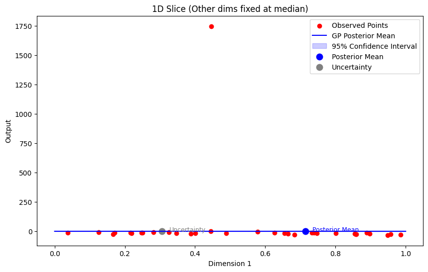

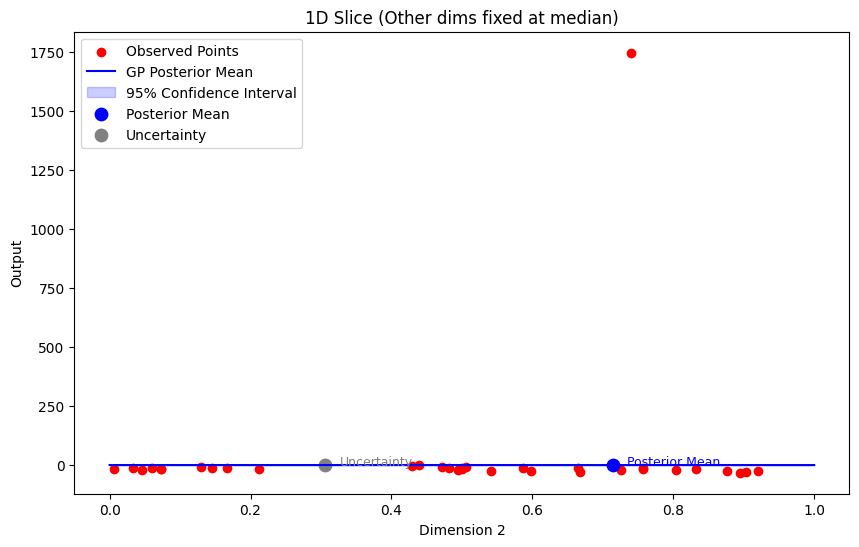

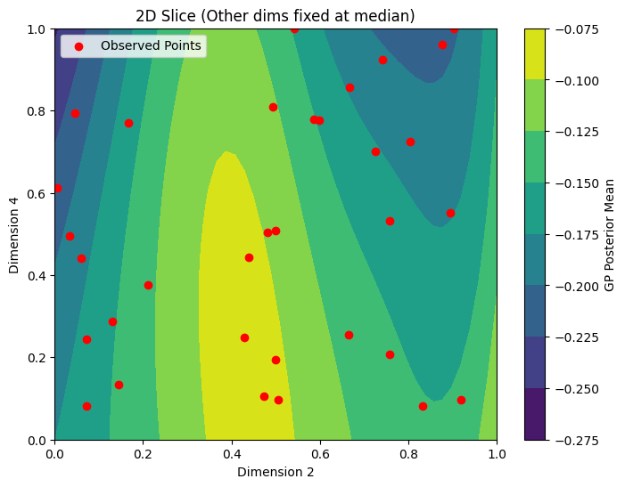

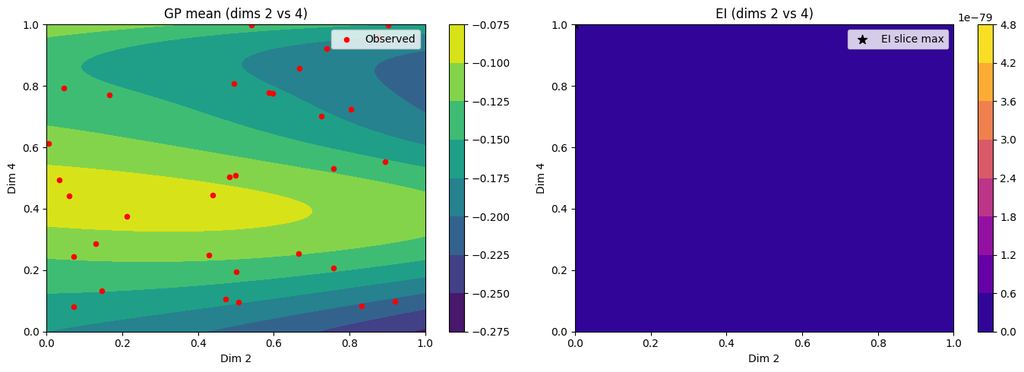

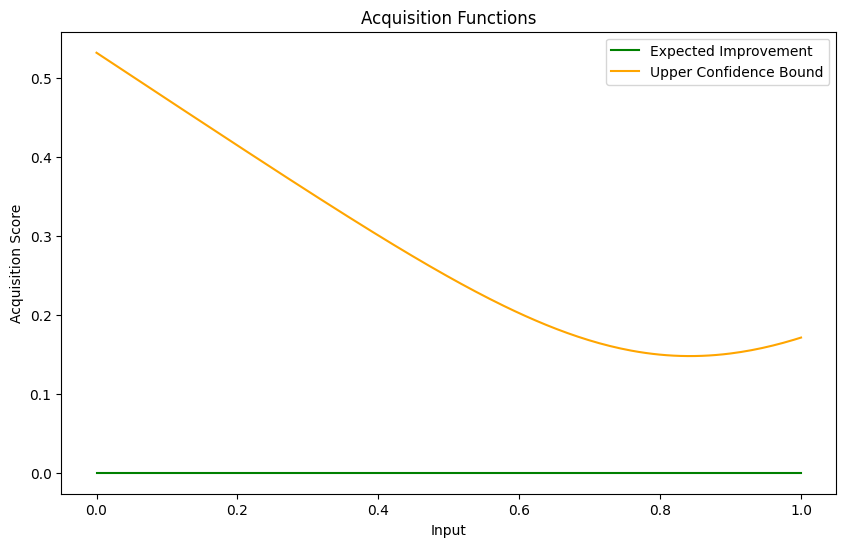

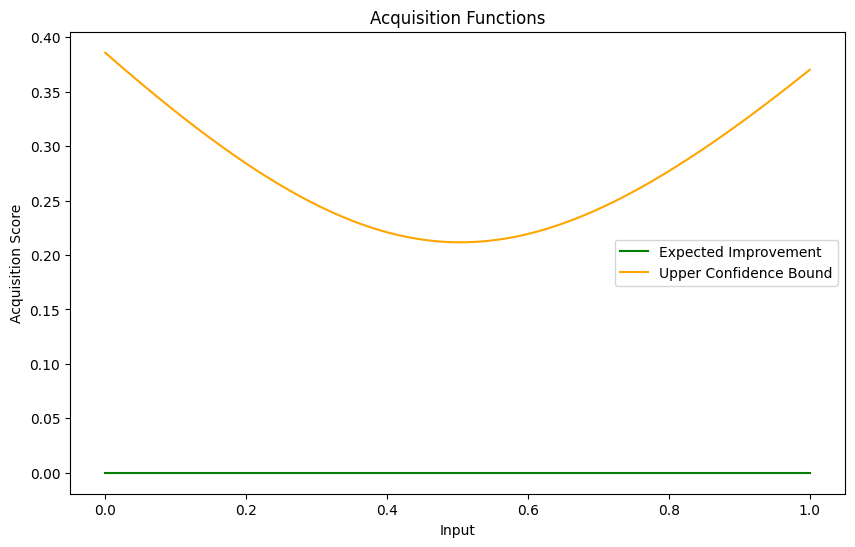

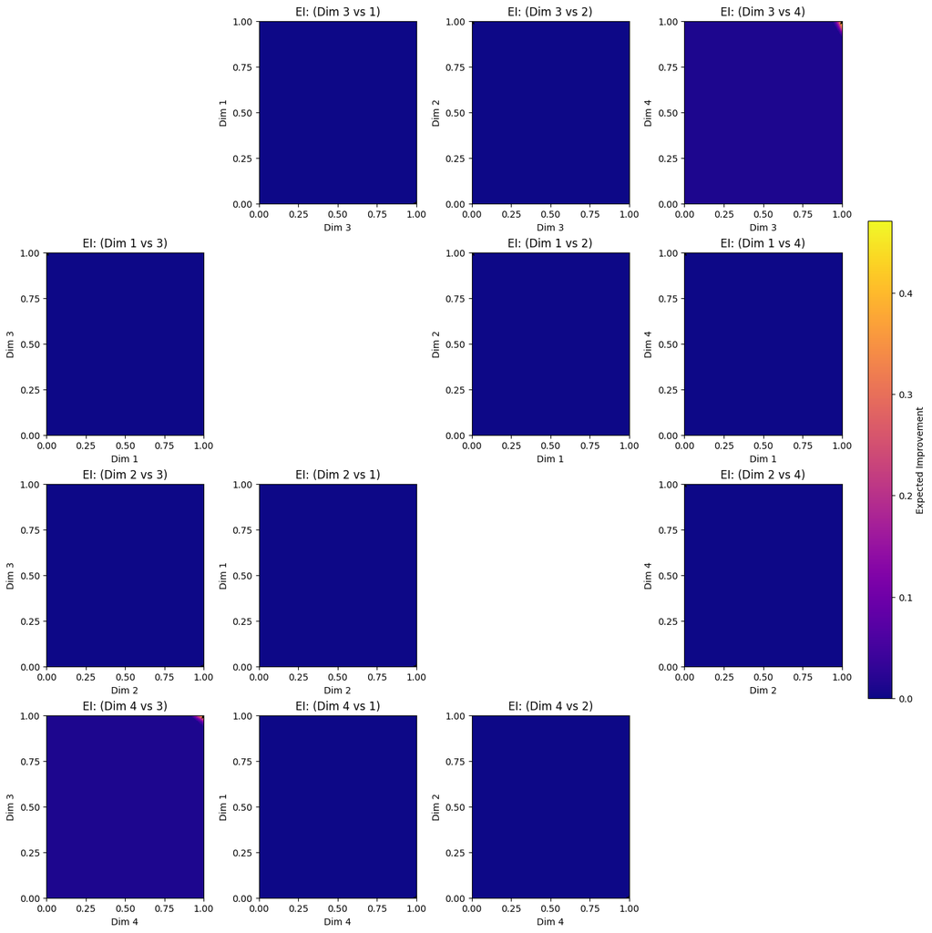

```python
# Visualize slices of the surrogate model
D = X.shape[1]
# 1D slice for dimension 1
plot_gp_slice(X, Y, gp, dims_to_vary=[0])

if D >= 2:
    plot_gp_slice(X, Y, gp, dims_to_vary=[1])
    # auto‑pick one 2D pair: the two dims with highest variance
    variances = np.var(X, axis=0)
    top2 = np.argsort(variances)[-2:]


# 2D slice for dimensions 1 and 2
plot_gp_slice(X, Y, gp, dims_to_vary=[int(top2[0]), int(top2[1])])
plot_2d_ei_slice(X, Y, gp, d1=int(top2[0]), d2=int(top2[1]), n_points=100, Y_best=float(np.max(getattr(gp, "y_train_", Y))))


# Visualize acquisition functions for dimension 1 slice
# For high dimensions, we show EI and UCB along the varied dimension
grid_dim1 = np.linspace(0, 1, 200)
X_full_dim1 = np.tile(np.median(X, axis=0), (200, 1))
X_full_dim1[:, 0] = grid_dim1
ei_dim1 = expected_improvement(X_full_dim1, gp, Y_best=float(np.max(gp.y_train_)))
ucb_dim1 = upper_confidence_bound(X_full_dim1, gp)
plot_acquisition_functions(grid_dim1, ei_dim1, ucb_dim1)

# Visualize acquisition functions for dimension 2 slice
if D >= 2:
    grid_dim2 = np.linspace(0, 1, 200)
    X_full_dim2 = np.tile(np.median(X, axis=0), (200, 1))
    X_full_dim2[:, 1] = grid_dim2
    ei_dim2  = expected_improvement(X_full_dim2, gp, Y_best=float(np.max(getattr(gp, "y_train_", Y))))
    ucb_dim2 = upper_confidence_bound(X_full_dim2, gp)
    plot_acquisition_functions(grid_dim2, ei_dim2, ucb_dim2)

# Pairplot of EI
pairplot_ei(X, Y, gp, n_dims=4, n_points=60, cmap="plasma")
```

### Generate Next Queries

Call propose_next_queries(...) and capture numeric + formatted outputs.

```python
# *** IMPORTANT: capture BOTH return values from the proposal function ***
numeric, formatted = propose_next_queries(X, Y, gp, cfg, k_final=5)
```

### Reporting

Print current best observation and proposed queries.

```python
# Console report
print(f"[{function_name}] shapes - X: {X.shape}, Y: {Y.shape}")
idx_best = int(np.argmax(Y))
print(f"[{function_name}] Current best Y: {float(Y[idx_best]):.6f} @ idx {idx_best}")
print("X_best:", np.array2string(X[idx_best], precision=6, separator=', '))


if formatted and len(formatted) > 0:
    print(f"\n[{function_name}] Proposed next queries (top {len(formatted)} by EI):")
    for i, fq in enumerate(formatted, 1):
        print(f" {i}. {fq}")
    print(f"[Portal] {function_name} top-1: {formatted[0]}")
else:
    print(f"\n[{function_path}] No candidates returned. "
          f"Consider increasing cfg.n_global_factor or lowering cfg.svm_keep_frac.")
```

```
[function_4] shapes - X: (33, 4), Y: (33,)
[function_4] Current best Y: 1747.711454 @ idx 31
X_best: [0.445848, 0.740499, 0.995147, 0.92283 ]

[function_4] Proposed next queries (top 5 by EI):
 1. 0.577766-0.500231-0.000306-0.008202
 2. 0.577766-0.500231-0.000607-0.021204
 3. 0.577766-0.500231-0.016825-0.004119
 4. 0.577766-0.500231-0.020432-0.002593
 5. 0.577766-0.500231-0.018199-0.010541
[Portal] function_4 top-1: 0.577766-0.500231-0.000306-0.008202
```